# Practical Machine Learning : Course Project Writeup

Thursday, June 19, 2014

### Introduction:

“Human Activity Recognition (HAR)” studies have gained more attention recently[1]. Using digital data of wearable accelerometers’ measurements, it’s now possible to predict personal activity with statistical significance. Our project is to make a model from data provided[2] with the use of machine learninng methods. Activities here are clasiffied into five such as ‘sitting’, ‘sitting down’, ‘standing’, ‘standing up’ and ‘walking’. Our work may involve creating tidy data, preprocessing data, building models and evaluation.

### Getting and Cleaning Data:

We download the datasets into a folda on our machine by clicking the links below and read the csv files separated by comma into R. The training dataset is composed of 19622 rows and 160 columns and testing dataset is 20 rows and 160 columns. Since the data are messy with lots of NAs and blanks, we want to reduce the number of columns at first along with the processes as follows;

- To check the column names of both files -> they have the same column names except for the last one,‘classe’ for the training file and ‘problem_id’ for testing:
- To reduce columns filled with NAs by using test file and pick up column names, and then create slimmed train dataset with the last column of ‘classe’. Now we have 60 columns:
- To reduce columns of ‘X’, ‘user_name’, 3 ‘timestanps’ and 2 ‘windows’, because they have nothing to do with accelerometers’ measurements. Then we have 53 columns:

There are discussions on whether or not to discard num_winows as a predictor. While there are pros to use it as predictor, it’s not sensor measurements, so it’s discarded this time.

```r
setwd("~/Coursera/PracticalMachineLearning")
train.raw<-read.table("pml-training.csv", header=T, sep=",")
test.raw<- read.table("pml-testing.csv", header=T,sep=",")
dim(train.raw); dim(test.raw);
```

```
## [1] 19622   160
```

```
## [1]  20 160
```

```r
train.name<-names(train.raw); test.name<-names(test.raw)
table(train.name==test.name)
```

```
##
## FALSE  TRUE
##     1   159
```

```r
#Reduce columns with NSs by using test file and creaate new training file with the same column names
test.clean<-test.raw[!sapply(test.raw, function(x) any(is.na(x)))]
test.clean.names<-names(test.clean)
test.clean.names[[60]]<-"classe" ; test.colnames<-unlist(test.clean.names)
train.clean<-train.raw[,test.colnames]
#Reduce non-sensor data columns and make tidy datasets
train.tidy<-train.clean[8:60]; test.tidy<-test.clean[8:60]
dim(train.tidy);dim(test.tidy);
```

```
## [1] 19622    53
```

```
## [1] 20 53
```

### Preprocessing Data:

Looking at the internal structure of the train.tidy dataset by “str” code, we find all columns except for ‘classe’ are numeric or integer and ‘classe’ is factor. Then we do principal component analysis (PCA) to find how big variance to explain the response variable the PCs have. 18 principal components ((note) not columns) explain more than 99% of the whole variance and each PC seems to not have so big variance because even the first PC has only 26% of the whole. We check correlations between variables too. We find that 11 pairs have very high correlationswhich are more than 0.9 with each other. Thinking that each data might be overfitting, we use 52 variables as a predictor this time because the PCA shows principal component doesn’t have overwelming impact and mechine learning methods usually involve cross validation or other method to make data unbiased within their calculation[3],

```r
str(train.tidy[,c(1:10, 53)])
```

```
## 'data.frame':    19622 obs. of  11 variables:
##  $ roll_belt       : num  1.41 1.41 1.42 1.48 1.48 1.45 1.42 1.42 1.43 1.45 ...
##  $ pitch_belt      : num  8.07 8.07 8.07 8.05 8.07 8.06 8.09 8.13 8.16 8.17 ...
##  $ yaw_belt        : num  -94.4 -94.4 -94.4 -94.4 -94.4 -94.4 -94.4 -94.4 -94.4 -94.4 ...
##  $ total_accel_belt: int  3 3 3 3 3 3 3 3 3 3 ...
##  $ gyros_belt_x    : num  0 0.02 0 0.02 0.02 0.02 0.02 0.02 0.02 0.03 ...
##  $ gyros_belt_y    : num  0 0 0 0 0.02 0 0 0 0 0 ...
##  $ gyros_belt_z    : num  -0.02 -0.02 -0.02 -0.03 -0.02 -0.02 -0.02 -0.02 -0.02 0 ...
##  $ accel_belt_x    : int  -21 -22 -20 -22 -21 -21 -22 -22 -20 -21 ...
##  $ accel_belt_y    : int  4 4 5 3 2 4 3 4 2 4 ...
##  $ accel_belt_z    : int  22 22 23 21 24 21 21 21 24 22 ...
##  $ classe          : Factor w/ 5 levels "A","B","C","D",..: 1 1 1 1 1 1 1 1 1 1 ...
```

```r
library(caret)
pr<-prcomp(train.tidy[,-53])
summary(pr)[[6]][,1:20]
```

```
##                             PC1      PC2      PC3      PC4       PC5
## Standard deviation     599.3361 534.1798 471.2424 378.5883 355.91845
## Proportion of Variance   0.2635   0.2093   0.1629   0.1051   0.09292
## Cumulative Proportion    0.2635   0.4728   0.6357   0.7408   0.83370
##                              PC6       PC7      PC8       PC9      PC10
## Standard deviation     254.51818 201.03284 173.5671 158.16406 118.24640
## Proportion of Variance   0.04751   0.02964   0.0221   0.01835   0.01026
## Cumulative Proportion    0.88122   0.91086   0.9330   0.95130   0.96156
##                            PC11     PC12     PC13     PC14     PC15
## Standard deviation     97.11690 89.62909 76.38275 68.47000 62.58078
## Proportion of Variance  0.00692  0.00589  0.00428  0.00344  0.00287
## Cumulative Proportion   0.96848  0.97437  0.97865  0.98209  0.98496
##                            PC16     PC17     PC18     PC19     PC20
## Standard deviation     56.73626 53.23824 49.73110 48.70005 41.92135
## Proportion of Variance  0.00236  0.00208  0.00181  0.00174  0.00129
## Cumulative Proportion   0.98732  0.98940  0.99121  0.99295  0.99424
```

```r
M<-abs(cor(train.tidy[,-53]))
diag(M)<-0
highcor<-which(M>0.9, arr.ind=T)
```

### Building a model:

In order to train data and test a model, We create two datasets, e.g. training and testing, from train.tidy dataset. Training dataset consists of 13737 rows and 53 columns and testing dataset 5885 and 53 respectively. We also see graphs of a couple of variables in training dataset. Models we try here are classification tree method, random forest and boosting method.

```r
inTrain<-createDataPartition(y=train.tidy$classe, p=0.7, list=F)
training<-train.tidy[ inTrain,]
testing<-train.tidy[-inTrain,]
dim(training); summary(training$classe);
```

```
## [1] 13737    53
```

```
##    A    B    C    D    E
## 3906 2658 2396 2252 2525
```

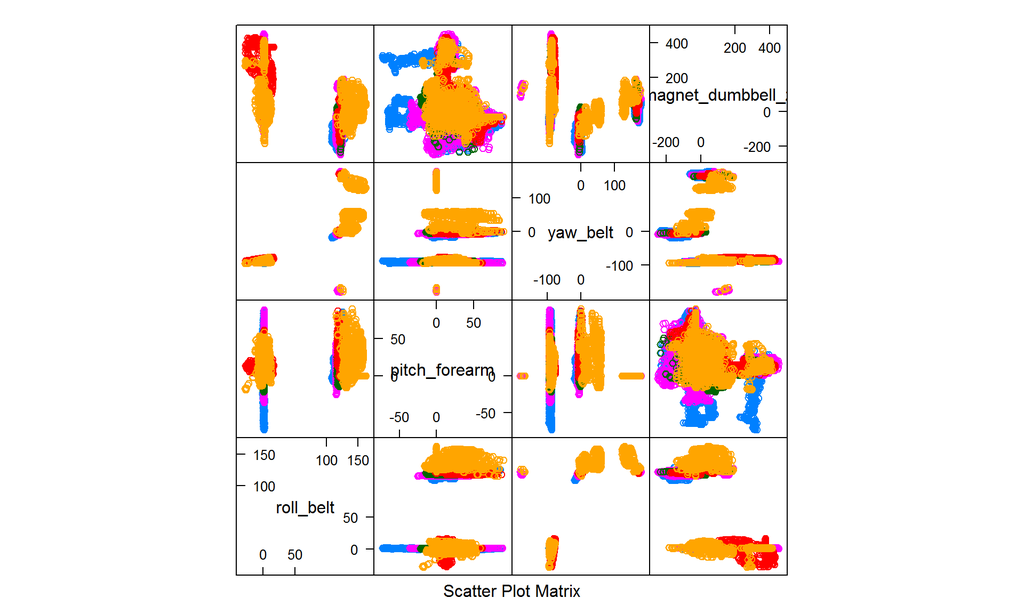

```r
library(ggplot2)
featurePlot(x=training[,c("roll_belt","pitch_forearm","yaw_belt","magnet_dumbbell_z")],
            y=training$classe, plot="pairs")
```

### Tree model

```r
treeFit<-train(classe~., data=train.tidy, method="rpart",
               trControl=trainControl(method="cv", number=4))
#treeFit$finalModel
#varImp(treeFit)
treePred<-predict(treeFit, testing)
confusionMatrix(treePred, testing$classe)
```

```
## Confusion Matrix and Statistics
##
##           Reference
## Prediction    A    B    C    D    E
##          A 1521  444  476  437  162
##          B   25  425   34  165  153
##          C  122  270  516  362  292
##          D    0    0    0    0    0
##          E    6    0    0    0  475
##
## Overall Statistics
##
##                Accuracy : 0.499
##                  95% CI : (0.486, 0.512)
##     No Information Rate : 0.284
##     P-Value [Acc > NIR] : <2e-16
##
##                   Kappa : 0.346
##  Mcnemar's Test P-Value : NA
##
## Statistics by Class:
##
##                      Class: A Class: B Class: C Class: D Class: E
## Sensitivity             0.909   0.3731   0.5029    0.000   0.4390
## Specificity             0.639   0.9206   0.7847    1.000   0.9988
## Pos Pred Value          0.500   0.5299   0.3303      NaN   0.9875
## Neg Pred Value          0.946   0.8595   0.8820    0.836   0.8877
## Prevalence              0.284   0.1935   0.1743    0.164   0.1839
## Detection Rate          0.258   0.0722   0.0877    0.000   0.0807
## Detection Prevalence    0.517   0.1363   0.2654    0.000   0.0817
## Balanced Accuracy       0.774   0.6468   0.6438    0.500   0.7189
```

```r
library(rattle)
```

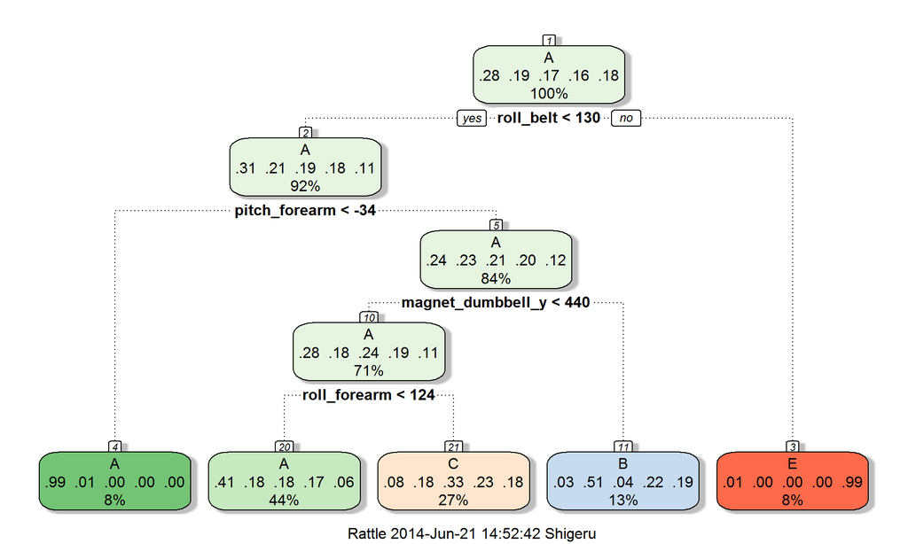

```r
fancyRpartPlot(treeFit$finalModel)
```

### Random forests model

```r
rfFit<-train(classe~., data=train.tidy, method="rf",
             trControl=trainControl(method="cv", number=4))
#rfFit$finalModel
rfPred<-predict(rfFit, testing)
confusionMatrix(rfPred, testing$classe)
```

```
## Confusion Matrix and Statistics
##
##           Reference
## Prediction    A    B    C    D    E
##          A 1674    0    0    0    0
##          B    0 1139    0    0    0
##          C    0    0 1026    0    0
##          D    0    0    0  964    0
##          E    0    0    0    0 1082
##
## Overall Statistics
##
##                Accuracy : 1
##                  95% CI : (0.999, 1)
##     No Information Rate : 0.284
##     P-Value [Acc > NIR] : <2e-16
##
##                   Kappa : 1
##  Mcnemar's Test P-Value : NA
##
## Statistics by Class:
##
##                      Class: A Class: B Class: C Class: D Class: E
## Sensitivity             1.000    1.000    1.000    1.000    1.000
## Specificity             1.000    1.000    1.000    1.000    1.000
## Pos Pred Value          1.000    1.000    1.000    1.000    1.000
## Neg Pred Value          1.000    1.000    1.000    1.000    1.000
## Prevalence              0.284    0.194    0.174    0.164    0.184
## Detection Rate          0.284    0.194    0.174    0.164    0.184
## Detection Prevalence    0.284    0.194    0.174    0.164    0.184
## Balanced Accuracy       1.000    1.000    1.000    1.000    1.000
```

```r
#varImp(rfFit)
```

### Boosting model

We do the similar processed in boosting method. As a result, it has *97% accuracy* which is very good.

```r
btFit<-train(classe~., data=train.tidy, method="gbm", verbose=F,
             trControl=trainControl(method="cv", number=4))
btPred<-predict(btFit, testing)
confusionMatrix(btPred, testing$classe)
```

```
## Confusion Matrix and Statistics
##
##           Reference
## Prediction    A    B    C    D    E
##          A 1656   22    0    1    0
##          B   10 1091   22    2    5
##          C    6   26  993   33    9
##          D    2    0   11  920   10
##          E    0    0    0    8 1058
##
## Overall Statistics
##
##                Accuracy : 0.972
##                  95% CI : (0.967, 0.976)
##     No Information Rate : 0.284
##     P-Value [Acc > NIR] : <2e-16
##
##                   Kappa : 0.964
##  Mcnemar's Test P-Value : NA
##
## Statistics by Class:
##
##                      Class: A Class: B Class: C Class: D Class: E
## Sensitivity             0.989    0.958    0.968    0.954    0.978
## Specificity             0.995    0.992    0.985    0.995    0.998
## Pos Pred Value          0.986    0.965    0.931    0.976    0.992
## Neg Pred Value          0.996    0.990    0.993    0.991    0.995
## Prevalence              0.284    0.194    0.174    0.164    0.184
## Detection Rate          0.281    0.185    0.169    0.156    0.180
## Detection Prevalence    0.285    0.192    0.181    0.160    0.181
## Balanced Accuracy       0.992    0.975    0.976    0.975    0.988
```

### Conclusion:

We are going to use the model with the highest accuracy, which is random forests. We have already ‘test.tidy’ dataset which is created from the first dataset, pml-testing csv file. New predictions are calculated for the answers to Course Project: Submission. It was already submitted and I got 20/20 correct.

```r
ans<-predict(rfFit, test.tidy)
ans
```

```
##  [1] B A B A A E D B A A B C B A E E A B B B
## Levels: A B C D E
```

### references:

[1]HAR research group provide their data and study results on the website as follows; http://groupware.les.inf.puc-rio.br/har

[2]Two datasets are available on the website as follows; 1)The training data:  
https://d396qusza40orc.cloudfront.net/predmachlearn/pml-training.csv 2)The test data:  
https://d396qusza40orc.cloudfront.net/predmachlearn/pml-testing.csv

[3] http://www.stat.berkeley.edu/~breiman/RandomForests/cc_home.htm#ooberr

[4]My machine’s spec is OS:64 bit windows 7 professional, RAM:8 GB, CPU: i7 2.8GHz